# 02 – Describing the Microbiome: Composition and Alpha Diversity

Blake Hanson, PhD

2026-01-12

# Goal for this section

In this notebook, we will focus on **describing the microbiome within samples** and **comparing within-sample diversity across sample groups**.

By the end of this notebook you will be able to:

1. Summarize the composition of a single sample at multiple taxonomy levels
2. Create bar plots of the most abundant taxa (OTU-level and labeled with taxonomy)
3. Visualize sequencing depth across samples and explain why rarefaction is used
4. Rarefy counts for **alpha diversity only** so metrics are calculated at a common depth
5. Calculate alpha diversity metrics and visualize differences across sample groups

> **Tip for Posit Cloud:** Run each code chunk in order using the green “Run” button.

## Step 1 — Load the phyloseq object

This notebook assumes you have already created a `phyloseq_object` in **Notebook 01** for our workshop data.

## Step 2 — Choose one sample to inspect in detail

A useful first step in microbiome data analysis is to examine a single sample and ask:

- Which taxa are present?
- Which taxa are most abundant?
- How “diverse” does this sample appear?

For this workshop, we start with a single example sample, **NEPS_356**, which is a Drain sample.

```r
# Create a variable for our target sample
target_sample <- "NEPS_356"
target_sample
```

```
## [1] "NEPS_356"
```

Before moving on, let’s confirm the sample exists within our phyloseq object

```r
# Print TRUE/FALSE if the target sample is in our phyloseq object
target_sample %in% sample_names(phyloseq_object)
```

```
## [1] TRUE
```

If the sample name is in the phyloseq object, this command will return the value “TRUE”.

## Step 3 — Subset the phyloseq object to the single sample

Subsetting lets us work with a simpler object and simplifies our required code for visualization.

```r
# Subset the phyloseq object to only our sample of interest
phyloseq_object_NEPS_356 <- prune_samples(sample_names(phyloseq_object) %in% target_sample, phyloseq_object)
# Subset the OTUs and taxonomy data to only taxa present in our sample of interest
phyloseq_object_NEPS_356 <- prune_taxa(taxa_sums(phyloseq_object_NEPS_356) > 0, phyloseq_object_NEPS_356)
```

```r
# Print the summary of the subset phyloseq object to show it only contains a single sample
phyloseq_object_NEPS_356
```

```
## phyloseq-class experiment-level object
## otu_table()   OTU Table:         [ 36 taxa and 1 samples ]
## sample_data() Sample Data:       [ 1 samples by 11 sample variables ]
## tax_table()   Taxonomy Table:    [ 36 taxa by 6 taxonomic ranks ]
```

## Step 4 — Create a table summarizing taxa in the sample (OTU + taxonomy + reads)

While phyloseq is a great container for microbiome data, we often need to extract our data into a standard R data frame for inspection, plotting, or statistics.

Here we are going to build a table that includes:

- OTU ID
- Genus (if available)
- The most resolved taxonomy level for each OTU
- Read/amplicon count
- Proportion/relative abundance within the sample

This mirrors a very common workflow in microbiome analysis: we combine **counts + taxonomy** into a single interpretable table.

### Step 4A — Create count and proportion vectors for the sample

This step converts our counts into proportions/relative abundance so we can see both in our table below.

```r
# Convert to relative abundance into proportions
phyloseq_object_NEPS_356_rel <- transform_sample_counts(
  phyloseq_object_NEPS_356,
  function(x) x / sum(x)
)

# Extract counts and proportions as named vectors for combining below into our single table
counts_vector <- as.vector(otu_table(phyloseq_object_NEPS_356))
names(counts_vector) <- taxa_names(phyloseq_object_NEPS_356)

props_vector <- as.vector(otu_table(phyloseq_object_NEPS_356_rel))
names(props_vector) <- taxa_names(phyloseq_object_NEPS_356_rel)
```

### Step 4B — Extract taxonomy and build the summary table

This step joins the taxonomy table to the counts/proportions for the sample.

```r
# Extract taxonomy table (lowercase ranks)
NEPS_356_taxonomy_tbl <- as.data.frame(tax_table(phyloseq_object_NEPS_356), stringsAsFactors = FALSE)

# Build tidy summary table that includes our OTU ID, the taxonomy, read/amplicon counts and proportions, and a label of the OTU ID and genus for plotting below
one_sample_summary <- NEPS_356_taxonomy_tbl %>%
  mutate(
    TaxonID = rownames(NEPS_356_taxonomy_tbl),
    Reads = counts_vector[TaxonID],
    Proportion = props_vector[TaxonID],
    Percent = Proportion*100
  ) %>%
  filter(!is.na(Reads) & Reads > 0) %>%
  arrange(desc(Reads)) %>%
  mutate(
    # Clean genus names
    genus = ifelse(
      is.na(genus) | genus == "" | genus %in% c("NA", "N/A", "unclassified"),
      NA,
      genus
    ),
    # A label of the OTU name and the
    GenusLabel = paste(TaxonID, genus, sep="-")
  )

# Let's visualize the table to make sure our formatting is correct
head(one_sample_summary)
```

```
##          domain         phylum               class             order
## OTU4   Bacteria     Firmicutes             Bacilli        Bacillales
## OTU59  Bacteria     Firmicutes             Bacilli   Lactobacillales
## OTU134 Bacteria Proteobacteria Gammaproteobacteria Enterobacteriales
## OTU136 Bacteria Proteobacteria Gammaproteobacteria Enterobacteriales
## OTU13  Bacteria     Firmicutes             Bacilli        Bacillales
## OTU1   Bacteria Actinobacteria      Actinobacteria   Actinomycetales
##                      family                           genus TaxonID Reads
## OTU4      Staphylococcaceae                  Staphylococcus    OTU4  3896
## OTU59      Streptococcaceae                   Streptococcus   OTU59  3628
## OTU134   Enterobacteriaceae unclassified_Enterobacteriaceae  OTU134  2786
## OTU136   Enterobacteriaceae                      Klebsiella  OTU136  1413
## OTU13     Staphylococcaceae                  Staphylococcus   OTU13   395
## OTU1   Propionibacteriaceae               Propionibacterium    OTU1   321
##        Proportion   Percent                             GenusLabel
## OTU4   0.27646892 27.646892                    OTU4-Staphylococcus
## OTU59  0.25745104 25.745104                    OTU59-Streptococcus
## OTU134 0.19770082 19.770082 OTU134-unclassified_Enterobacteriaceae
## OTU136 0.10026966 10.026966                      OTU136-Klebsiella
## OTU13  0.02803009  2.803009                   OTU13-Staphylococcus
## OTU1   0.02277888  2.277888                 OTU1-Propionibacterium
```

## Step 5 — Plot the top taxa in the sample (OTU / Taxon IDs)

Now that we have a summary table, we can visualize the most abundant taxa in the sample.

We start by plotting the top OTUs using the **TaxonID** variable. We also only want to visualize our top 15 most abundant OTUs as the more we visualize the more difficult this can be to interpret. Choosing 15 OTUs to plot is completely arbitrary and we could choose 10, 20, or any other reasonably assessable whole number.

```r
library(ggplot2)

# Set our top N value for subsetting below
top_n <- 15
top_n
```

```
## [1] 15
```

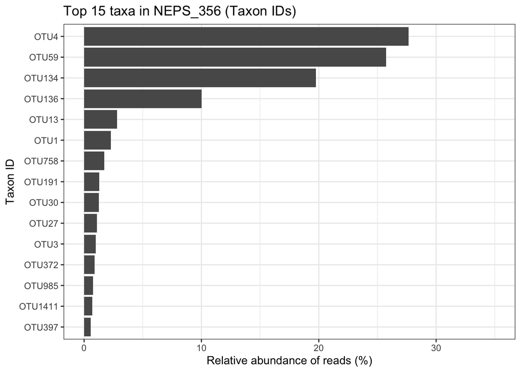

```r
# Create our subset dataframe of our summary table for only the top N OTUs
plot_df <- one_sample_summary %>%
  slice_head(n = top_n) %>%
  mutate(TaxonID = factor(TaxonID, levels = rev(TaxonID)))

# Plot a bar plot of the relative abundance of the reads
ggplot(plot_df, aes(x = TaxonID, y = Percent)) +
  geom_col() +
  coord_flip() +
  theme_bw() +
  ylim(0,35) +
  labs(
    title = paste0("Top ", top_n, " taxa in ", target_sample, " (Taxon IDs)"),
    x = "Taxon ID",
    y = "Relative abundance of reads (%)"
  )
```

We can see that this is a relatively simple community that is dominated by four OTUs (with relative abundance >5%), but it is difficult to see what those OTUs are. Next, we will add in our taxonomy tables to the plot to make this more interpretable.

## Step 6 — Plot the top taxa in the sample (Taxon ID + genus suffix)

Taxon IDs are unique, but they are not very interpretable biologically. Let’s label our bar plot using our variable **GenusLabel** that includes the TaxonID and genus values separated by a dash.

This keeps labels unique while giving biological context (and avoids duplicate factor-level errors).

Additionally, we explicitly convert TaxonID to a factor ordered by relative abundance so that this ordering can be reused in later plots.

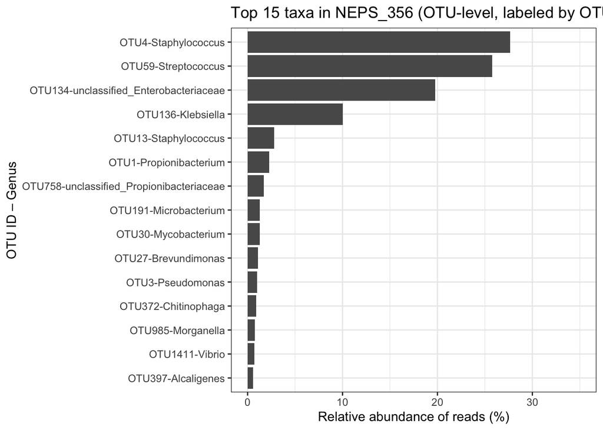

```r
# A feature/quirk of ggplot2 is it orders bars using factor levels, so when we change the x-axis variables we need to explicitly tell R to keep the same ordering.
plot_df_temp <- one_sample_summary %>%
  slice_head(n = top_n) %>%
  mutate(
    OrderVar = factor(TaxonID, levels = rev(TaxonID))
  )
genus_levels <- plot_df_temp$GenusLabel[match(levels(plot_df_temp$OrderVar), plot_df_temp$OrderVar)]
plot_df_2 <- plot_df_temp %>%
  mutate(
    GenusLabel = factor(GenusLabel, levels = genus_levels)
  )

# Plot a bar plot of the relative abundance of the reads
ggplot(plot_df_2, aes(x = GenusLabel, y = Percent)) +
  geom_col() +
  coord_flip() +
  theme_bw() +
  ylim(0, 35) +
  labs(
    title = paste0(
      "Top ", top_n, " taxa in ", target_sample,
      " (OTU-level, labeled by OTU ID and genus)"
    ),
    x = "OTU ID – Genus",
    y = "Relative abundance of reads (%)"
  )
```

Now that we have looked at our single sample, we can move to our full-project alpha diversity assessments.

## Step 7 — Alpha diversity: sequencing depth across samples (why rarefaction matters)

Alpha diversity metrics can depend strongly on sequencing depth. If one sample has 5,000 reads and another has 50,000 reads, the deeper sample will often appear more diverse simply because we observed more reads. To account for this, we are going to rarefy our data. This is only admissible for alpha diversity metrics and we will go back to our un-rarefied phyloseq object for our other analyses today. If you would like to read more on why rarefaction is only OK for alpha diversity, please see [Waste Not, Want Not: Why Rarefying Microbiome Data is Inadmissible](https://journals.plos.org/ploscompbiol/article?id=10.1371/journal.pcbi.1003531) by McMurdie and Holmes.

Before calculating alpha diversity, we will:

1. Summarize reads per sample
2. Plot reads per sample
3. Choose a depth threshold
4. Rarefy counts **for alpha diversity only**

### Step 7A — Build a sequencing depth table

```r
# To assess our sequencing depth per sample, first we want to pull out the information we need from the phyloseq object into a dedicated data frame
depth_df <- data.frame(
  SampleID = sample_names(phyloseq_object),
  Reads = sample_sums(phyloseq_object),
  Material = as.character(sample_data(phyloseq_object)$Material),
  stringsAsFactors = FALSE
)

# Now, let's look at the summary statistics for our dataset and take a look at the top of the table we have created
summary(depth_df$Reads)
```

```
##    Min. 1st Qu.  Median    Mean 3rd Qu.    Max.
##    5007   15954   35149   52685   72640  500371
```

```r
head(depth_df)
```

```
##          SampleID  Reads Material
## NEPS_100 NEPS_100  37517      ADM
## NEPS_101 NEPS_101  19405   Breast
## NEPS_102 NEPS_102  38979     Skin
## NEPS_103 NEPS_103  46214  Capsule
## NEPS_104 NEPS_104 125835       TE
## NEPS_106 NEPS_106  13698   Breast
```

## Step 8 — Plot sequencing depth by sample group

This plot helps us see whether certain sample types systematically have lower read depth, and it helps motivate why we might filter or rarefy.

We are going to use a log scale here because read depth is often spread across multiple orders of magnitude.

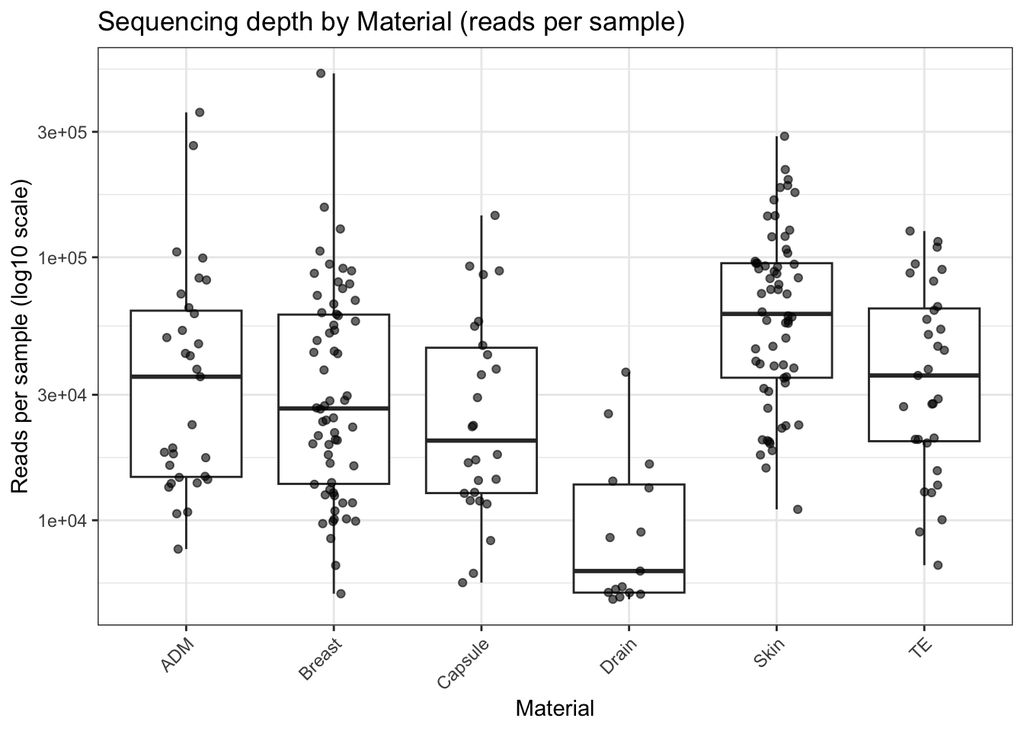

```r
ggplot(depth_df, aes(x = Material, y = Reads)) +
  geom_boxplot(outlier.alpha = 0.25) +
  geom_jitter(width = 0.15, alpha = 0.6, size = 1.5) +
  scale_y_log10() +
  theme_bw() +
  theme(axis.text.x = element_text(angle = 45, hjust = 1)) +
  labs(
    title = "Sequencing depth by Material (reads per sample)",
    x = "Material",
    y = "Reads per sample (log10 scale)"
  )
```

## Step 9 — Choose a rarefaction depth for alpha diversity

For the workshop, we will rarefy to a fixed depth so that alpha diversity is computed on the same number of reads per sample.

In many workflows, you either:

- rarefy to the **minimum** depth (keeps all samples but may be low), or
- choose a threshold and **drop samples below it** (often preferable)

Here we will use a depth threshold of **5,000 reads**. The 5,000-read threshold is chosen for teaching purposes and because that is what we used in the publication. In real analyses this choice depends on study design and sequencing depth.

```r
min_reads <- 5000
min_reads
```

```
## [1] 5000
```

```r
# Keep only samples with at least 5,000 reads
ps_alpha_input <- prune_samples(sample_sums(phyloseq_object) >= min_reads, phyloseq_object)

# After removing samples, drop taxa that are now all-zero
ps_alpha_input <- prune_taxa(taxa_sums(ps_alpha_input) > 0, ps_alpha_input)

cat("Original samples:", nsamples(phyloseq_object), "\n")
```

```
## Original samples: 227
```

```r
cat("Samples with >= 5000 reads:", nsamples(ps_alpha_input), "\n")
```

```
## Samples with >= 5000 reads: 227
```

For simplicity, the dataset we are using has already had all failing samples dropped from it, but this is an important decision to make in your analyses.

## Step 10 — Rarefy the dataset (alpha diversity only)

Rarefaction involves random subsampling of reads. We are going to set a seed so that the results are reproducible during the workshop. You can set the seed to any value you would like and the subsampling will become deterministic, we are choosing seed 1234.

```r
set.seed(1234)

ps_rarefied <- rarefy_even_depth(
  ps_alpha_input,
  sample.size = min_reads,
  replace = FALSE,
  trimOTUs = TRUE,
  verbose = FALSE
)

# Our summary should now show every value is 5,000
summary(sample_sums(ps_rarefied))
```

```
##    Min. 1st Qu.  Median    Mean 3rd Qu.    Max.
##    5000    5000    5000    5000    5000    5000
```

We can now see that our summary is all 5,000. This shows that our rarifaction was successful.

## Step 11 — Calculate alpha diversity metrics

We will calculate several commonly used alpha diversity metrics:

- Observed richness
- Shannon diversity
- Inverse Simpson diversity

```r
# Generate the table of alpha diversity for each sample across our selected diversity metrics
alpha_all <- estimate_richness(
  ps_rarefied,
  measures = c("Observed", "Shannon", "InvSimpson")
)

# Make sure the sample IDs are carried over
alpha_all$SampleID <- rownames(alpha_all)

# Let's look at the top of the new table to make sure the format is what we expect
head(alpha_all)
```

```
##          Observed   Shannon InvSimpson SampleID
## NEPS_100       53 1.1666341   1.538356 NEPS_100
## NEPS_101       17 1.2914013   2.537396 NEPS_101
## NEPS_102       45 1.5912717   3.534575 NEPS_102
## NEPS_103       19 0.9406525   1.626128 NEPS_103
## NEPS_104       22 1.0273025   2.077985 NEPS_104
## NEPS_106       24 1.9924542   4.241753 NEPS_106
```

## Step 12 — Visualize alpha diversity by sample group (phyloseq-native)

A simple approach is to use the phyloseq command `plot_richness()`, which pulls metadata directly from the phyloseq object.

We will plot alpha diversity across `Material` categories to see whether within-sample diversity differs by sample type.

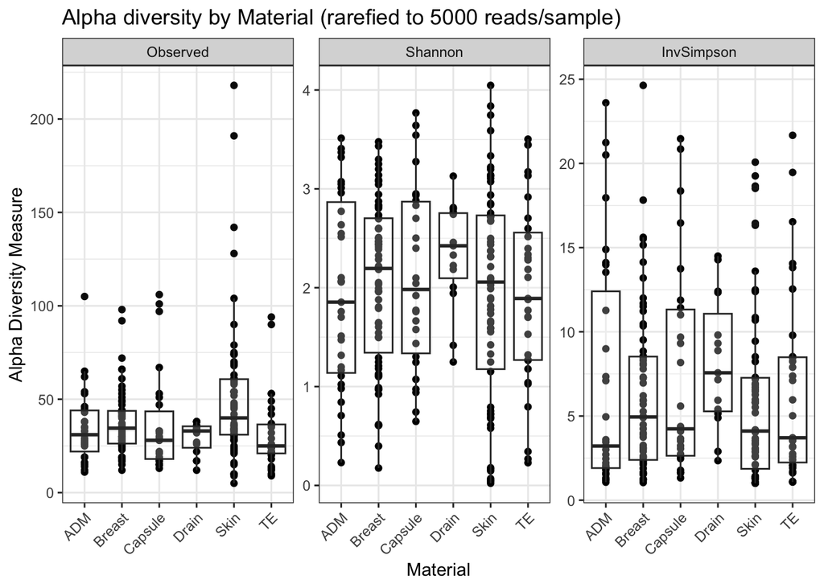

```r
# Create the richness plot by material
plot_richness(
  ps_rarefied,
  x = "Material",
  measures = c("Observed", "Shannon", "InvSimpson")
) +
  geom_boxplot(aes(group = Material), alpha = 0.25, outlier.alpha = 0.25) +
  theme_bw() +
  theme(axis.text.x = element_text(angle = 45, hjust = 1)) +
  labs(
    title = paste0("Alpha diversity by Material (rarefied to ", min_reads, " reads/sample)")
  )
```

## Step 13 — (Optional) View alpha diversity values alongside metadata

Sometimes it is helpful to inspect diversity values and metadata in the same table (for QC or for quick sanity checks before statistics).

```r
# Create a data frame of the sample_data to merge with the alpha diversity statistics created above
meta_df <- as.data.frame(sample_data(ps_rarefied), check.names = FALSE)
class(meta_df) <- "data.frame"

# Merge the metadata and alpha diversity statistics
alpha_with_meta <- cbind(
  alpha_all,
  meta_df[alpha_all$SampleID, , drop = FALSE]
)

# Let's look at the top of the new table to assure formatting and merging worked as expected
head(alpha_with_meta)
```

```
##          Observed   Shannon InvSimpson SampleID Patient_ID Patient Timepoint
## NEPS_100       53 1.1666341   1.538356 NEPS_100        E-2       E         3
## NEPS_101       17 1.2914013   2.537396 NEPS_101        E-2       E         3
## NEPS_102       45 1.5912717   3.534575 NEPS_102        E-2       E         3
## NEPS_103       19 0.9406525   1.626128 NEPS_103        E-2       E         3
## NEPS_104       22 1.0273025   2.077985 NEPS_104        E-2       E         3
## NEPS_106       24 1.9924542   4.241753 NEPS_106        E-1       E         1
##          SampleSide Material MaterialTime ExtractionBatch SpikeIn ABX
## NEPS_100       Left      ADM          ADM               3      No  No
## NEPS_101      Right   Breast     Breast_3               3      No  No
## NEPS_102      Right     Skin       Skin_3               3      No  No
## NEPS_103      Right  Capsule      Capsule               3      No  No
## NEPS_104      Right       TE           TE               3      No  No
## NEPS_106       Left   Breast     Breast_1               3      No  No
##          CancerSide CancerSideSample
## NEPS_100      Right               No
## NEPS_101      Right              Yes
## NEPS_102      Right              Yes
## NEPS_103      Right              Yes
## NEPS_104      Right              Yes
## NEPS_106      Right               No
```

# Summary

In this notebook, we:

- Examined the composition of a single sample and visualized its most abundant taxa
- Used taxonomy to improve interpretability of OTU-level plots
- Visualized sequencing depth and explained why depth matters for alpha diversity
- Filtered low-depth samples and rarefied to a common depth **for alpha diversity only**
- Calculated and visualized alpha diversity metrics across sample types

In the next notebook, we will focus on **beta diversity and ordination**, where we compare samples based on overall community composition.